# Analyses - paper FunctionalLands

## by Bruno X. Pinho

First, it is important to emphasize that the between region variance of the FC_scale variables is 31%, while the within-region variance is 69%. There is thus considerable within-region variation, the effect of which can be studied. Also, there is not much climate variation within regions (less then 3.5%), and the between regions effect of climate has been previously assessed.

**Load packages/functions**

```r
setwd("C:/Users/Bruno/Google Drive/Papers/Novos/Functional_Lands/Data")

library(dplyr)
```

```r
library(ggplot2)
library(sjPlot)
library(ggpubr)
source("function_Multifit.R")
```

**Load data**

```r
data_lands <- read.csv("data_lands.csv", header = TRUE, sep = ",", row.names = 1)
names(data_lands)
```

```
##  [1] "X"             "Region"        "Region_Plot"   "Latitude"
##  [5] "Longitude"     "DistEq"        "Annual_Precip" "Annual_Temp"
##  [9] "Precip_Seas"   "Aridity"       "PET"           "soilpH"
## [13] "Temp_Seas"     "Alpha.taylor"  "Patch_size"    "ED"
## [17] "FC_1ha"        "FC_5ha"        "FC_10ha"       "FC_25ha"
## [21] "FC_50ha"       "FC_100ha"      "FC_200ha"      "FC_300ha"
## [25] "FC_400ha"      "FC_500ha"      "ED_1ha"        "ED_5ha"
## [29] "ED_10ha"       "ED_25ha"       "ED_50ha"       "ED_100ha"
## [33] "ED_200ha"      "ED_300ha"      "ED_400ha"      "ED_500ha"
## [37] "FD.nbsp"       "LA"            "SLA"           "LDMC"
## [41] "WD"            "SM"            "Hmax"          "FD.FRic"
## [45] "FD.FDis"       "FD.RaoQ"       "LA_ba"         "SLA_ba"
## [49] "LDMC_ba"       "WD_ba"         "SM_ba"         "Hmax_ba"
## [53] "Fric_ba"       "Fdis_ba"       "Rao_ba"        "SES_Fdis"
## [57] "SES_Fric"
```

```r
data_lands <- data_lands[-44,]
```

**Check response distributions** *(note that some species traits have been transformed before)*

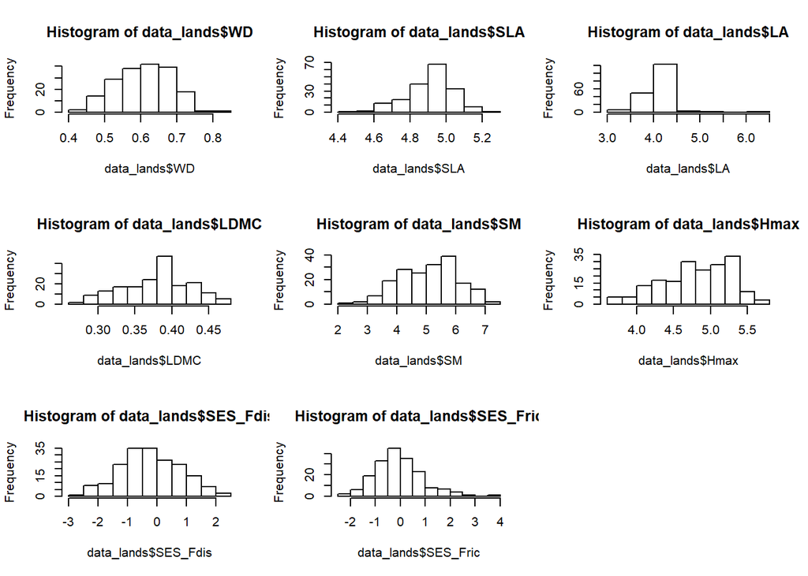

```r
par(mfrow=c(3,3))

hist(data_lands$WD)
hist(data_lands$SLA)
hist(data_lands$LA)
hist(data_lands$LDMC)
hist(data_lands$SM)
hist(data_lands$Hmax)
hist(data_lands$SES_Fdis)
hist(data_lands$SES_Fric)
```

**Scale of effect by trait/region** *(Automatized by function “multifit”, see Huais 2018)*

**WD**

*Lacandona*

```
## The model including the effect 'FC_50ha' was the best model according to the specified criterion (R2, which.max)
```

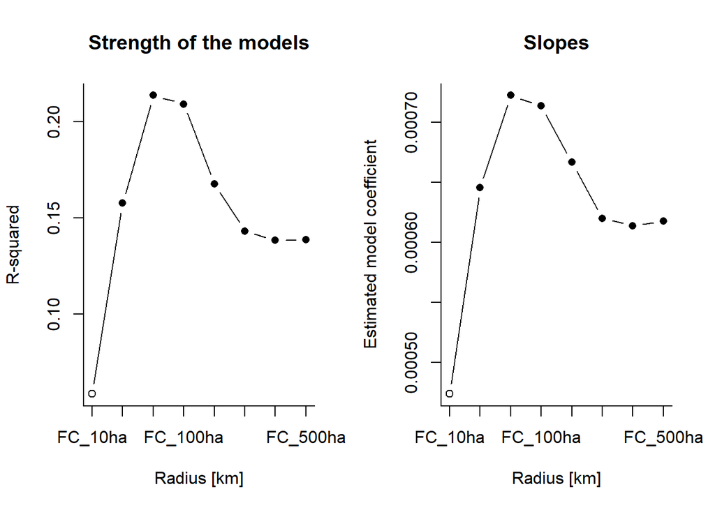

```r
data_LCD <- filter(data_lands, Region=="LCD")
WD_FC_LCD <- multifit(mod = "lm", multief = colnames(data_LCD)[19:26],
                      formula = WD ~ multief,
                      data = data_LCD, criterion = "R2", plot_est = T)
```

*Los Tuxtlas*

```
## The model including the effect 'FC_10ha' was the best model according to the specified criterion (R2, which.max)
```

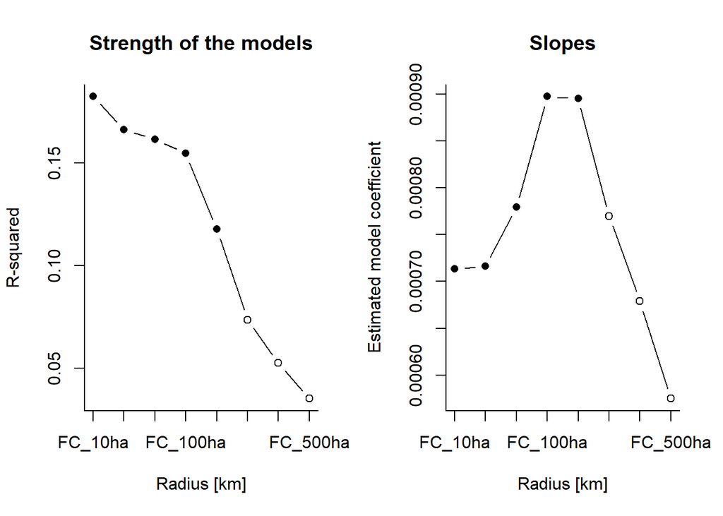

```r
data_LTX <- filter(data_lands, Region=="LTX")
WD_FC_LTX <- multifit(mod = "lm", multief = colnames(data_LTX)[19:26],
                      formula = WD ~ multief,
                      data = data_LTX, criterion = "R2", plot_est = T)
```

*Balbina*

```
## The model including the effect 'FC_100ha' was the best model according to the specified criterion (R2, which.max)
```

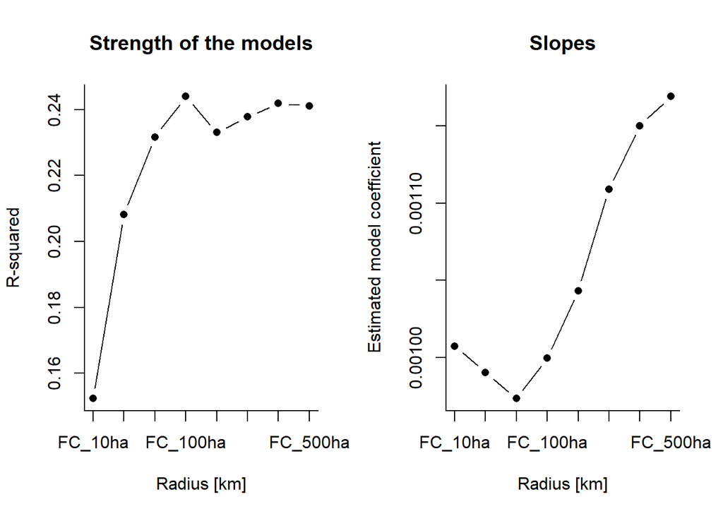

```r
data_Balb <- filter(data_lands, Region=="Balbina")
WD_FC_Balb<- multifit(mod = "lm", multief = colnames(data_Balb)[19:26],
                      formula = WD ~ multief,
                      data = data_Balb, criterion = "R2", plot_est = T)
```

*Paraiba*

```
## The model including the effect 'FC_50ha' was the best model according to the specified criterion (R2, which.max)
```

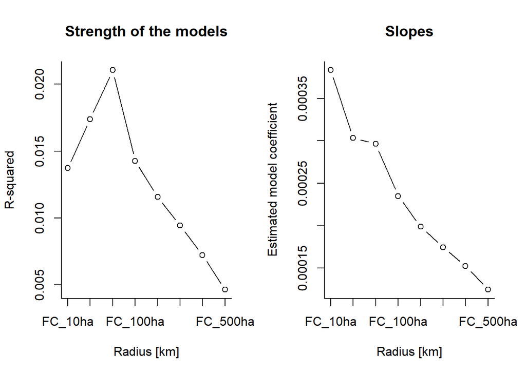

```r
data_PB <- filter(data_lands, Region=="PB")
WD_FC_PB<- multifit(mod = "lm", multief = colnames(data_PB)[19:26],
                    formula = WD ~ multief,
                    data = data_PB, criterion = "R2", plot_est = T)
```

*Serra Grande*

```
## The model including the effect 'FC_500ha' was the best model according to the specified criterion (R2, which.max)
```

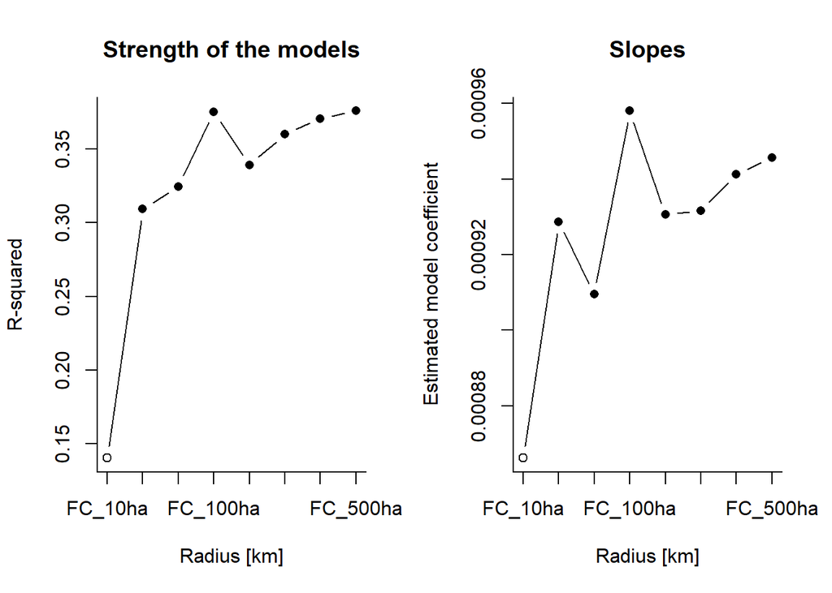

```r
data_SGD <- filter(data_lands, Region=="SGD")
WD_FC_SGD<- multifit(mod = "lm", multief = colnames(data_SGD)[19:26],
                     formula = WD ~ multief,
                     data = data_SGD, criterion = "R2", plot_est = T)
```

*Una*

```
## The model including the effect 'FC_100ha' was the best model according to the specified criterion (R2, which.max)
```

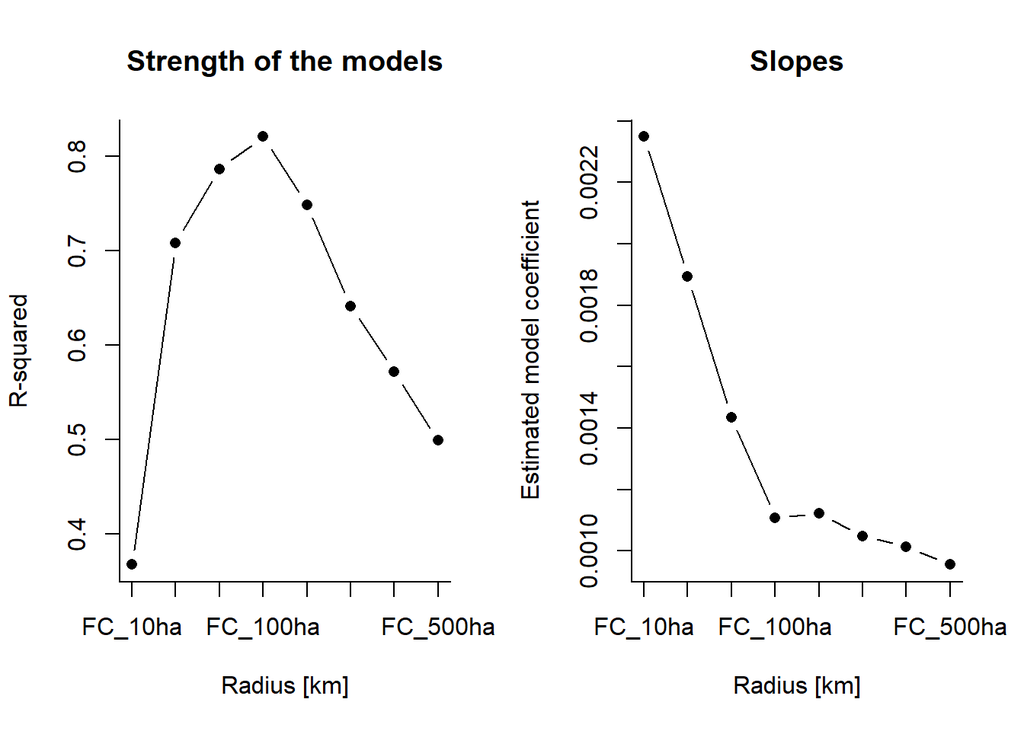

```r
data_Una <- filter(data_lands, Region=="Una")
WD_FC_Una<- multifit(mod = "lm", multief = colnames(data_Una)[19:26],
                     formula = WD ~ multief,
                     data = data_Una, criterion = "R2", plot_est = T)
```

*Serra Tabuleiro*

```
## The model including the effect 'FC_400ha' was the best model according to the specified criterion (R2, which.max)
```

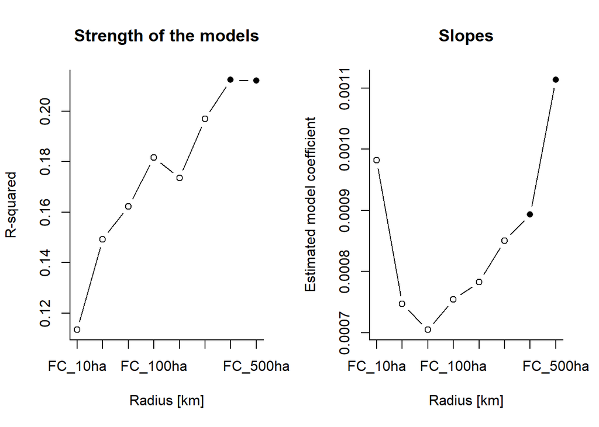

```r
data_STB <- filter(data_lands, Region=="STB")
WD_FC_STB<- multifit(mod = "lm", multief = colnames(data_STB)[19:26],
                     formula = WD ~ multief,
                     data = data_STB, criterion = "R2", plot_est = T)
```

**SLA**

*Lacandona*

```
## The model including the effect 'FC_50ha' was the best model according to the specified criterion (R2, which.max)
```

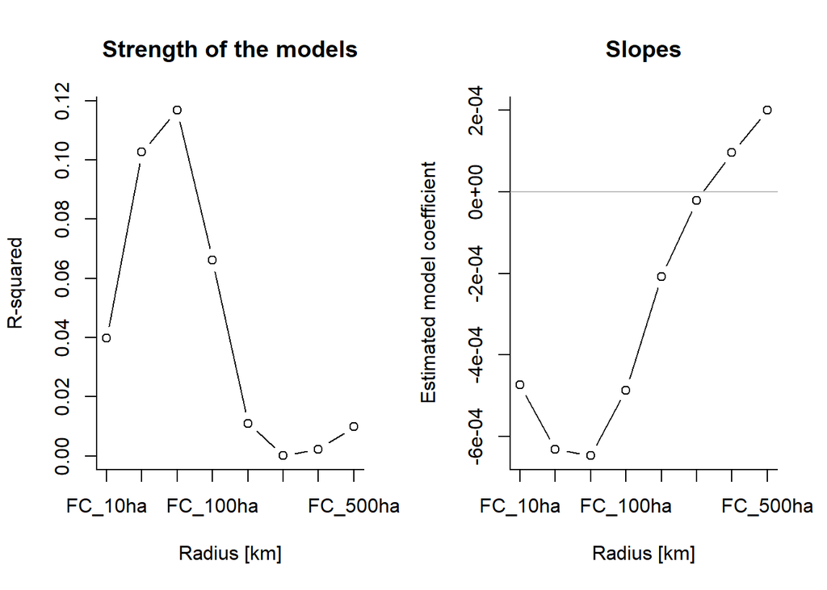

```r
SLA_FC_LCD <- multifit(mod = "lm", multief = colnames(data_LCD)[19:26],
                        formula = SLA ~ multief,
                        data = data_LCD, criterion = "R2", plot_est = T)
```

*Los Tuxtlas*

```
## The model including the effect 'FC_100ha' was the best model according to the specified criterion (R2, which.max)
```

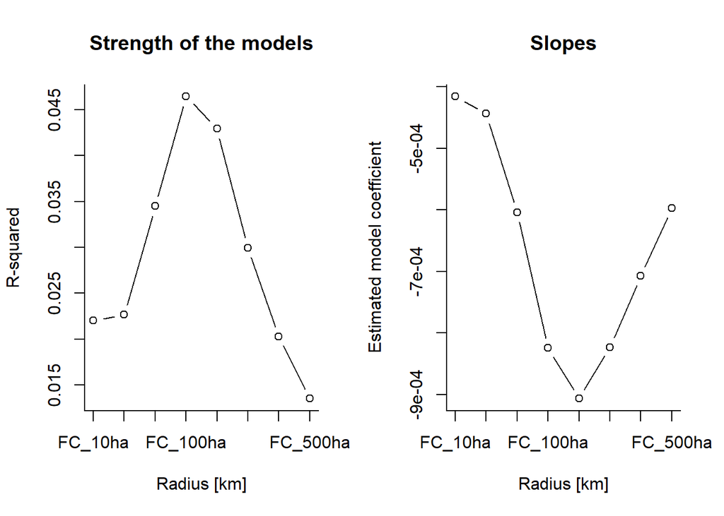

```r
SLA_FC_LTX <- multifit(mod = "lm", multief = colnames(data_LTX)[19:26],
                        formula = SLA ~ multief,
                        data = data_LTX, criterion = "R2", plot_est = T)
```

*Balbina*

```
## The model including the effect 'FC_25ha' was the best model according to the specified criterion (R2, which.max)
```

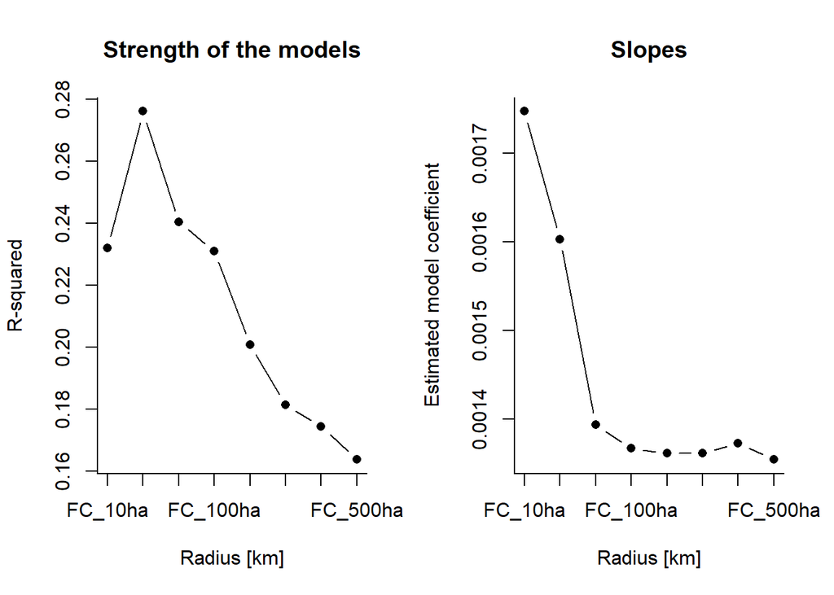

```r
SLA_FC_Balb<- multifit(mod = "lm", multief = colnames(data_Balb)[19:26],
                        formula = SLA ~ multief,
                        data = data_Balb, criterion = "R2", plot_est = T)
```

*Paraiba*

```
## The model including the effect 'FC_10ha' was the best model according to the specified criterion (R2, which.max)
```

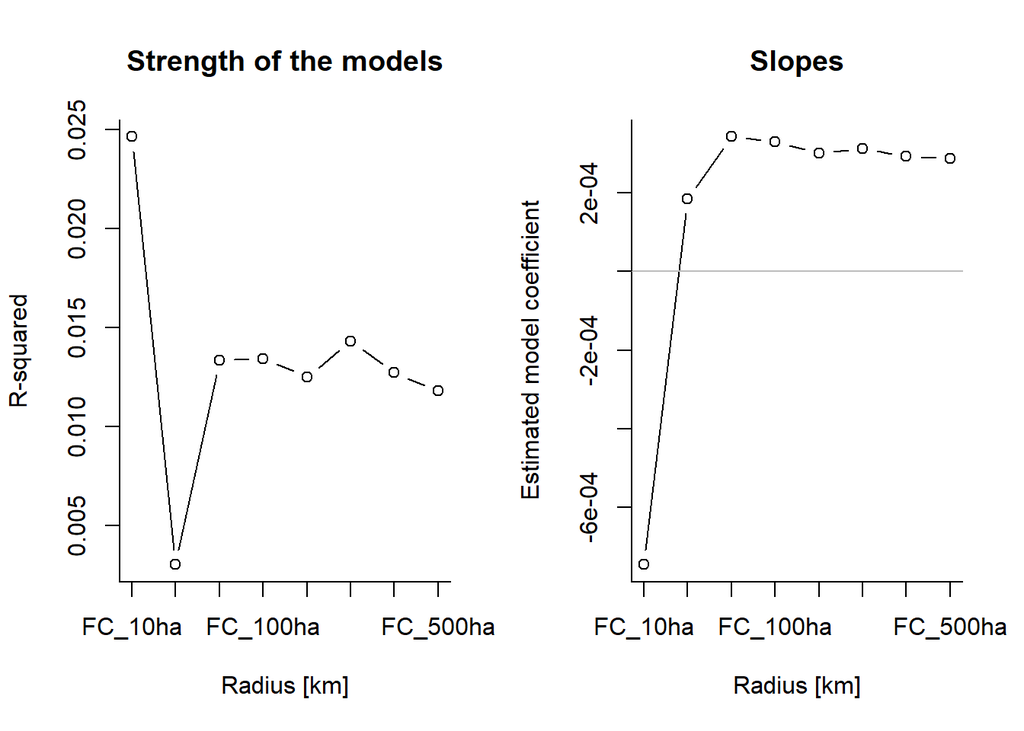

```r
SLA_FC_PB<- multifit(mod = "lm", multief = colnames(data_PB)[19:26],
                      formula = SLA ~ multief,
                      data = data_PB, criterion = "R2", plot_est = T)
```

*Serra Grande*

```
## The model including the effect 'FC_100ha' was the best model according to the specified criterion (R2, which.max)
```

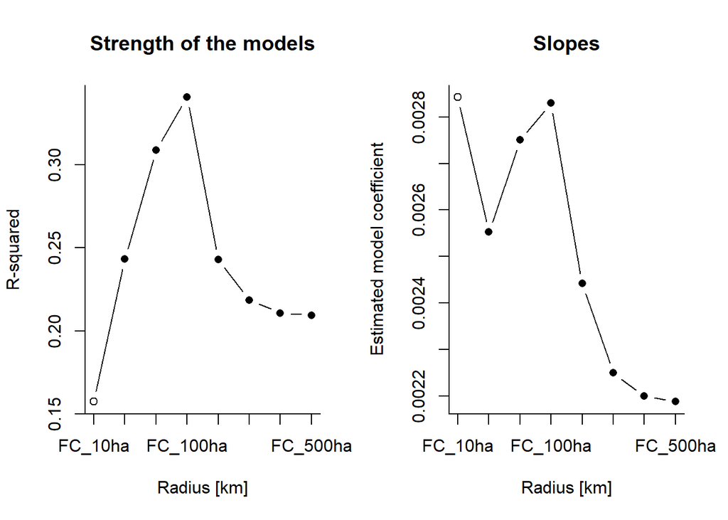

```r
SLA_FC_SGD<- multifit(mod = "lm", multief = colnames(data_SGD)[19:26],
                       formula = SLA ~ multief,
                       data = data_SGD, criterion = "R2", plot_est = T)
```

*Una*

```
## The model including the effect 'FC_200ha' was the best model according to the specified criterion (R2, which.max)
```

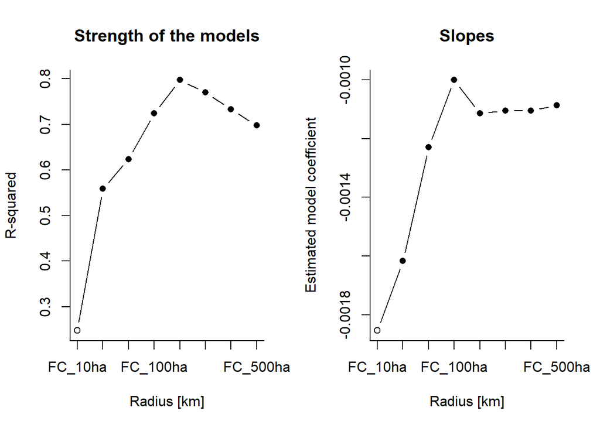

```r
SLA_FC_Una<- multifit(mod = "lm", multief = colnames(data_Una)[19:26],
                       formula = SLA ~ multief,
                       data = data_Una, criterion = "R2", plot_est = T)
```

*Serra Tabuleiro*

```
## The model including the effect 'FC_200ha' was the best model according to the specified criterion (R2, which.max)
```

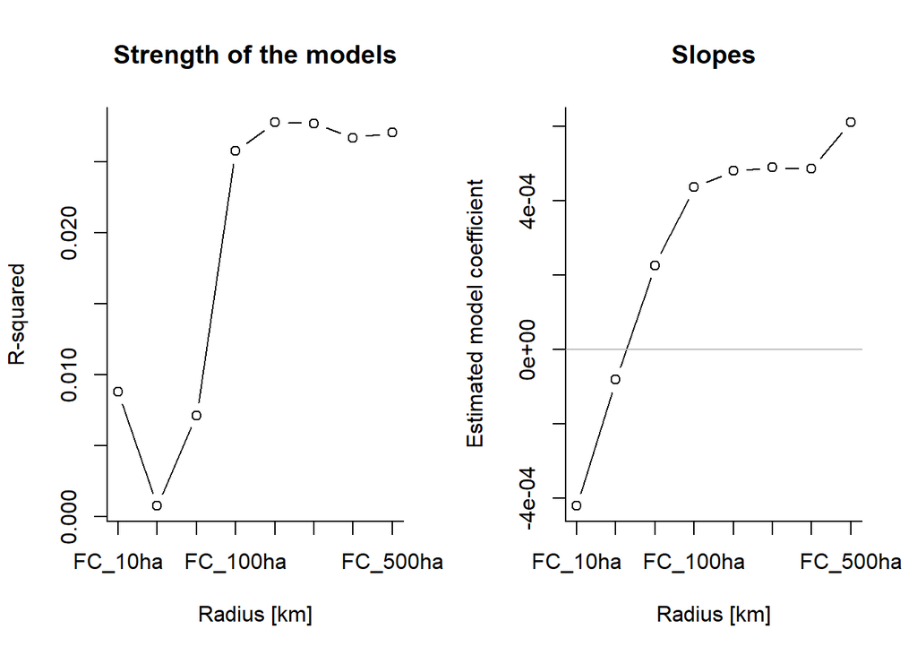

```r
SLA_FC_STB<- multifit(mod = "lm", multief = colnames(data_STB)[19:26],
                       formula = SLA ~ multief,
                       data = data_STB, criterion = "R2", plot_est = T)
```

**Seed mass**

*Lacandona*

```
## The model including the effect 'FC_500ha' was the best model according to the specified criterion (R2, which.max)
```

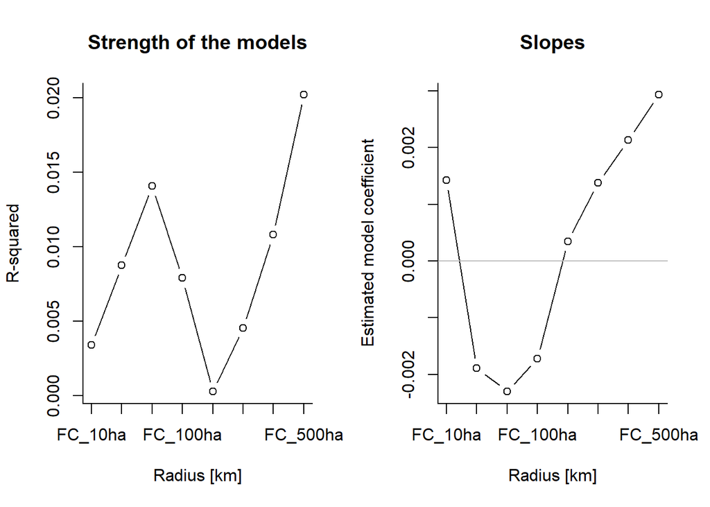

```r
SM_FC_LCD <- multifit(mod = "lm", multief = colnames(data_LCD)[19:26],
                       formula = SM ~ multief,
                       data = data_LCD, criterion = "R2", plot_est = T)
```

*Los Tuxtlas*

```
## The model including the effect 'FC_200ha' was the best model according to the specified criterion (R2, which.max)
```

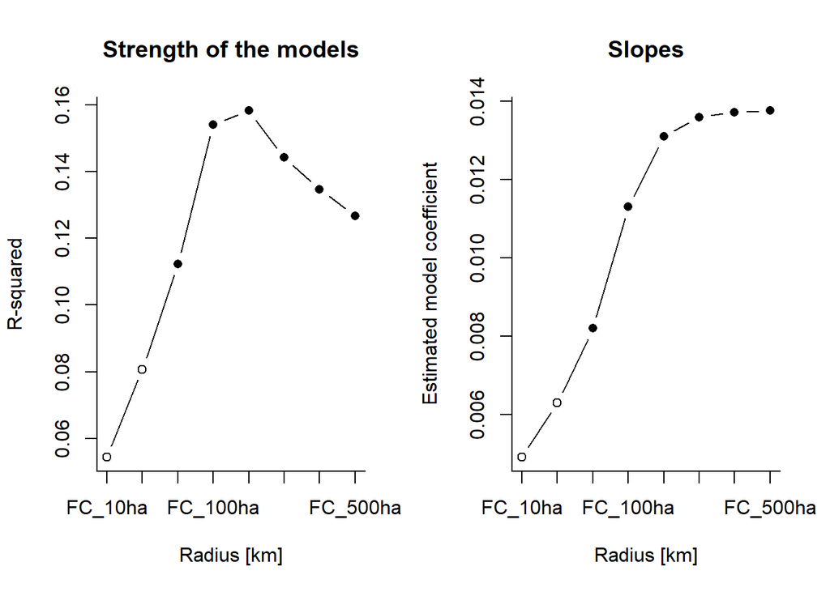

```r
SM_FC_LTX <- multifit(mod = "lm", multief = colnames(data_LTX)[19:26],
                       formula = SM ~ multief,
                       data = data_LTX, criterion = "R2", plot_est = T)
```

*Balbina*

```
## The model including the effect 'FC_100ha' was the best model according to the specified criterion (R2, which.max)
```

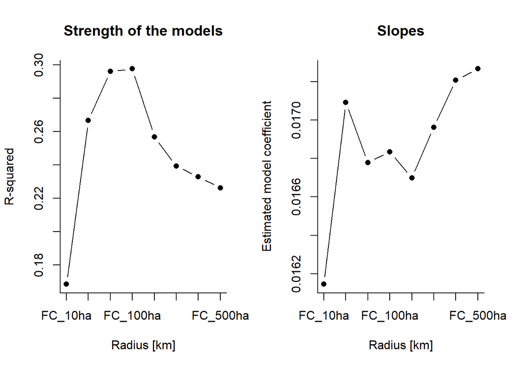

```r
SM_FC_Balb<- multifit(mod = "lm", multief = colnames(data_Balb)[19:26],
                       formula = SM ~ multief,
                       data = data_Balb, criterion = "R2", plot_est = T)
```

*Paraiba*

```
## The model including the effect 'FC_100ha' was the best model according to the specified criterion (R2, which.max)
```

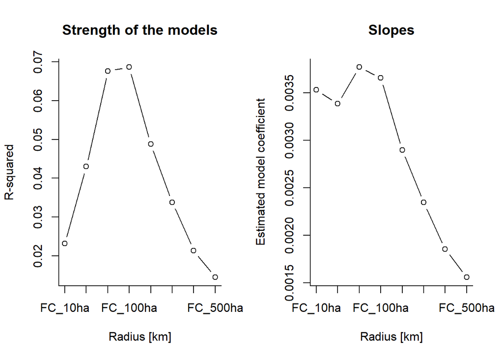

```r
SM_FC_PB<- multifit(mod = "lm", multief = colnames(data_PB)[19:26],
                     formula = SM ~ multief,
                     data = data_PB, criterion = "R2", plot_est = T)
```

*Serra Grande*

```
## The model including the effect 'FC_500ha' was the best model according to the specified criterion (R2, which.max)
```

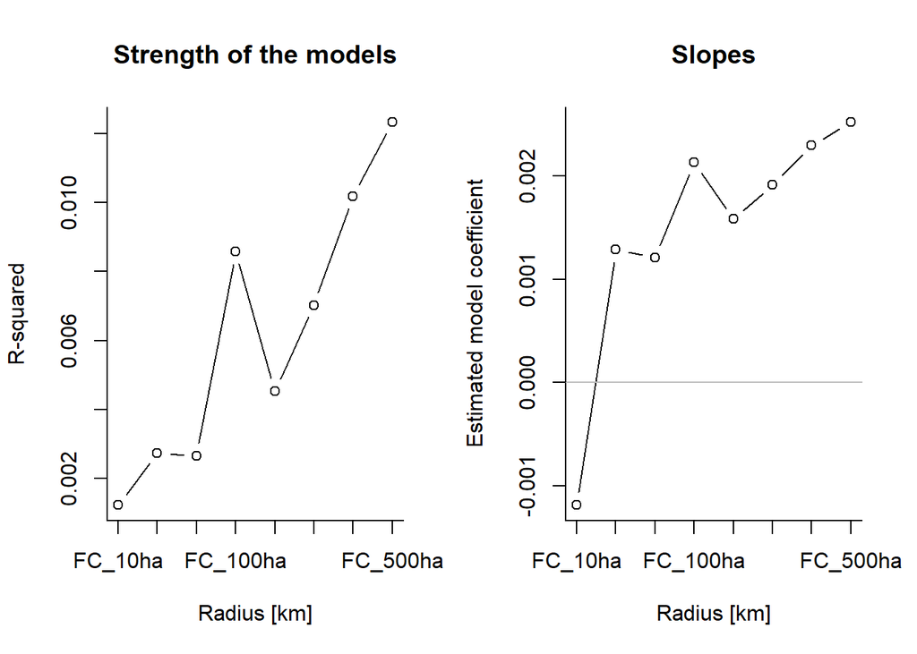

```r
SM_FC_SGD<- multifit(mod = "lm", multief = colnames(data_SGD)[19:26],
                      formula = SM ~ multief,
                      data = data_SGD, criterion = "R2", plot_est = T)
```

*Una*

```
## The model including the effect 'FC_500ha' was the best model according to the specified criterion (R2, which.max)
```

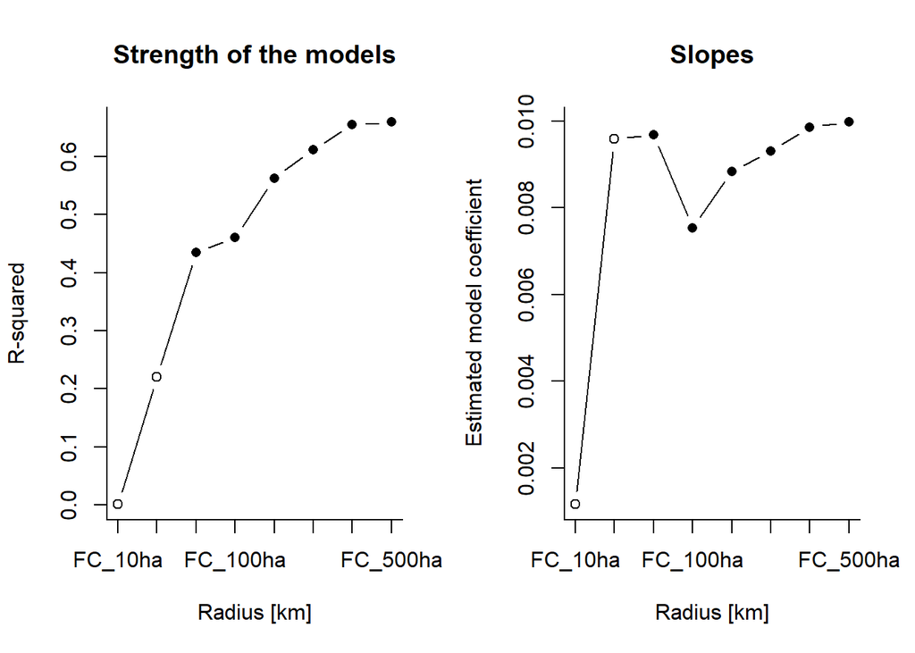

```r
SM_FC_Una<- multifit(mod = "lm", multief = colnames(data_Una)[19:26],
                      formula = SM ~ multief,
                      data = data_Una, criterion = "R2", plot_est = T)
```

*Serra Tabuleiro*

```
## The model including the effect 'FC_500ha' was the best model according to the specified criterion (R2, which.max)
```

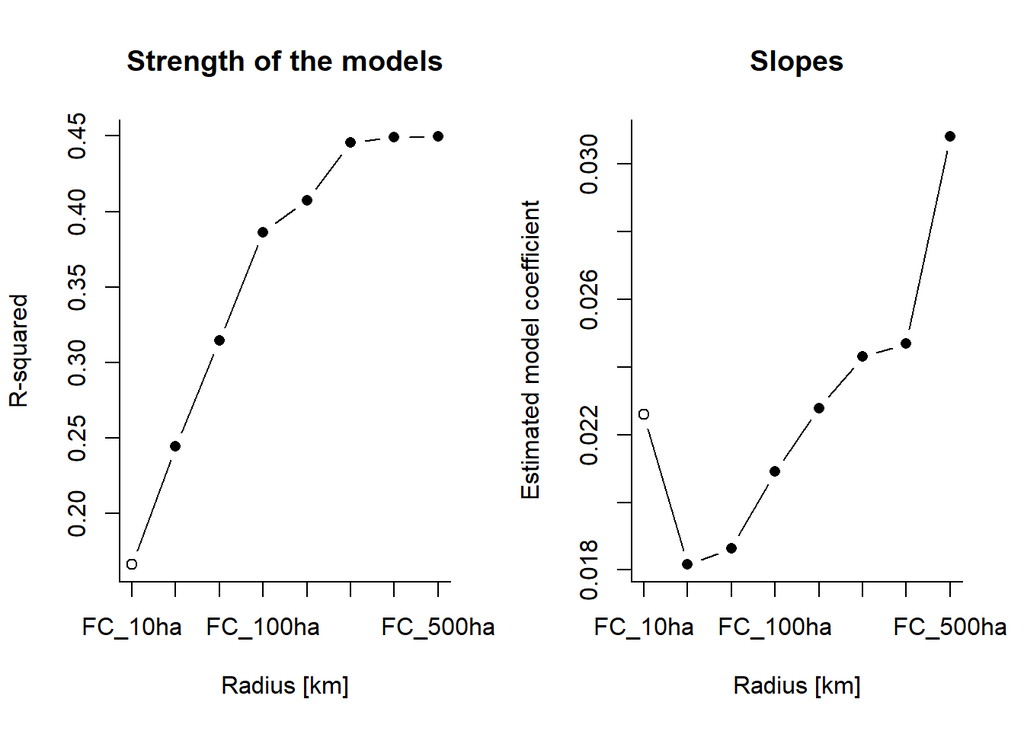

```r
SM_FC_STB<- multifit(mod = "lm", multief = colnames(data_STB)[19:26],
                      formula =SM ~ multief,
                      data = data_STB, criterion = "R2", plot_est = T)
```

*Lacandona*

```
## The model including the effect 'FC_10ha' was the best model according to the specified criterion (R2, which.max)
```

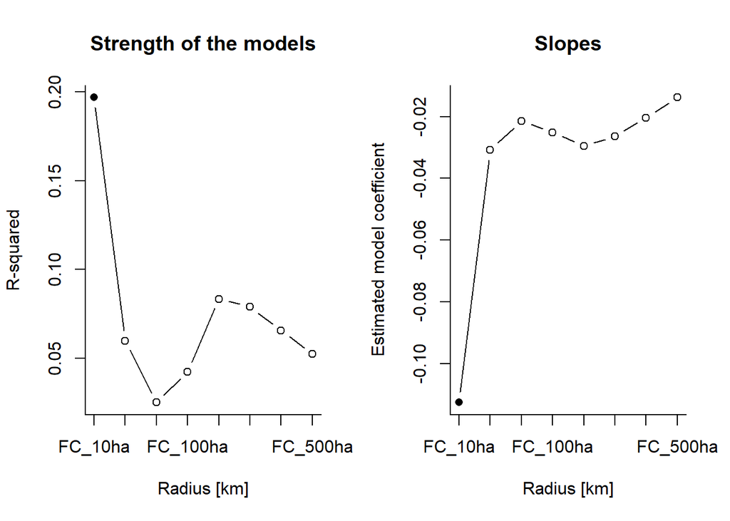

```r
Fric_FC_LCD <- multifit(mod = "lm", multief = colnames(data_LCD)[19:26],
                        formula = SES_Fric ~ multief+I(multief^2),
                        data = data_LCD, criterion = "R2", plot_est = T)
```

*Los Tuxtlas*

```
## The model including the effect 'FC_10ha' was the best model according to the specified criterion (R2, which.max)
```

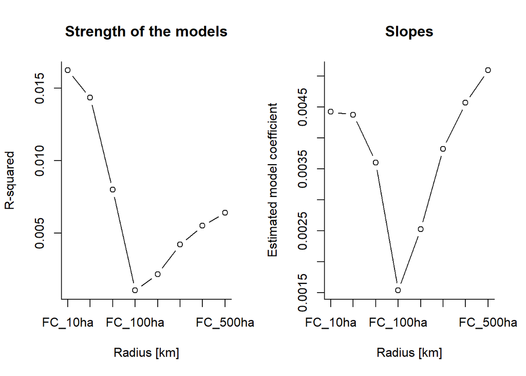

```r
Fric_FC_LTX <- multifit(mod = "lm", multief = colnames(data_LTX)[19:26],
                        formula = SES_Fric ~ multief,
                        data = data_LTX, criterion = "R2", plot_est = T)
```

*Balbina*

```
## The model including the effect 'FC_100ha' was the best model according to the specified criterion (R2, which.max)
```

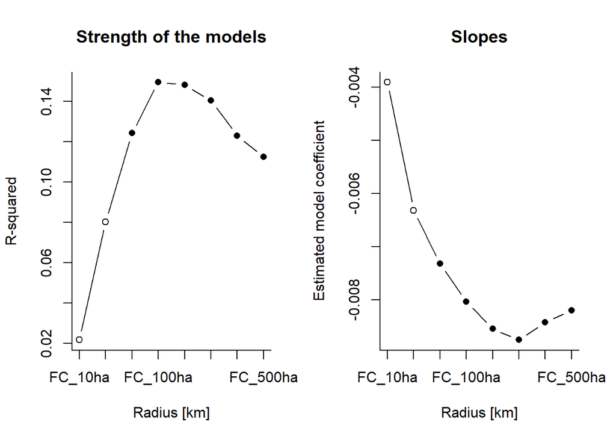

```r
Fric_FC_Balb<- multifit(mod = "lm", multief = colnames(data_Balb)[19:26],
                        formula = SES_Fric ~ multief,
                        data = data_Balb, criterion = "R2", plot_est = T)
```

*Paraiba*

```
## The model including the effect 'FC_400ha' was the best model according to the specified criterion (R2, which.max)
```

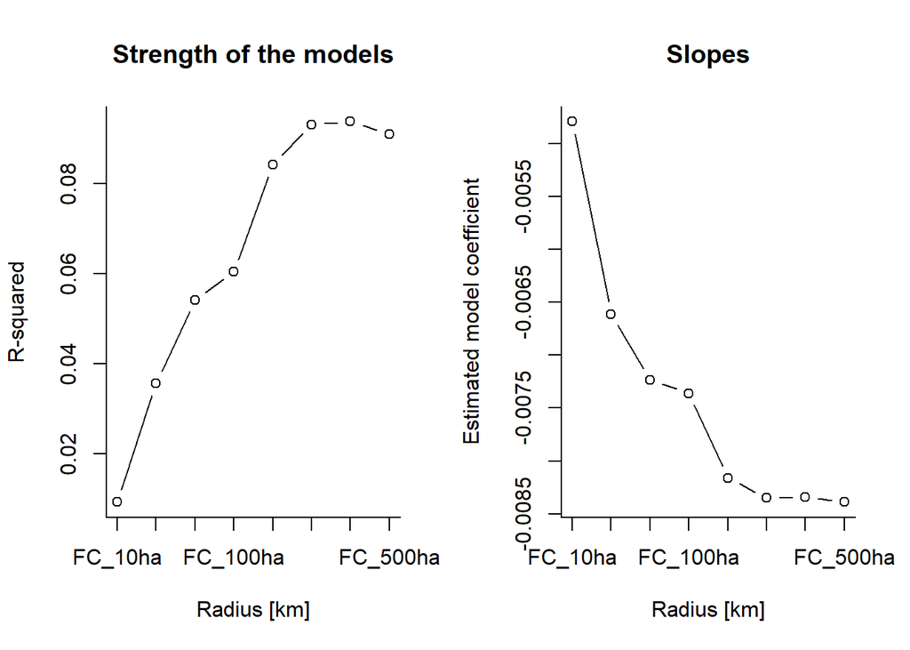

```r
Fric_FC_PB<- multifit(mod = "lm", multief = colnames(data_PB)[19:26],
                      formula = SES_Fric ~ multief,
                      data = data_PB, criterion = "R2", plot_est = T)
```

*Serra Grande*

```
## The model including the effect 'FC_100ha' was the best model according to the specified criterion (R2, which.max)
```

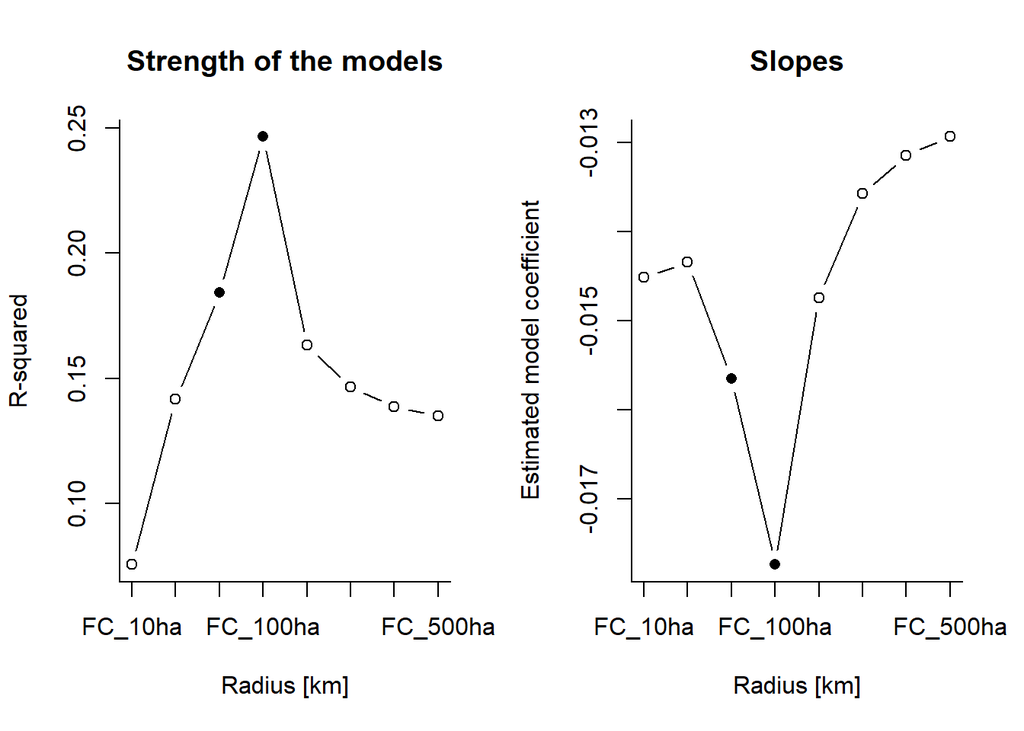

```r
Fric_FC_SGD<- multifit(mod = "lm", multief = colnames(data_SGD)[19:26],
                       formula = SES_Fric ~ multief,
                       data = data_SGD, criterion = "R2", plot_est = T)
```

*Una*

```
## The model including the effect 'FC_500ha' was the best model according to the specified criterion (R2, which.max)
```

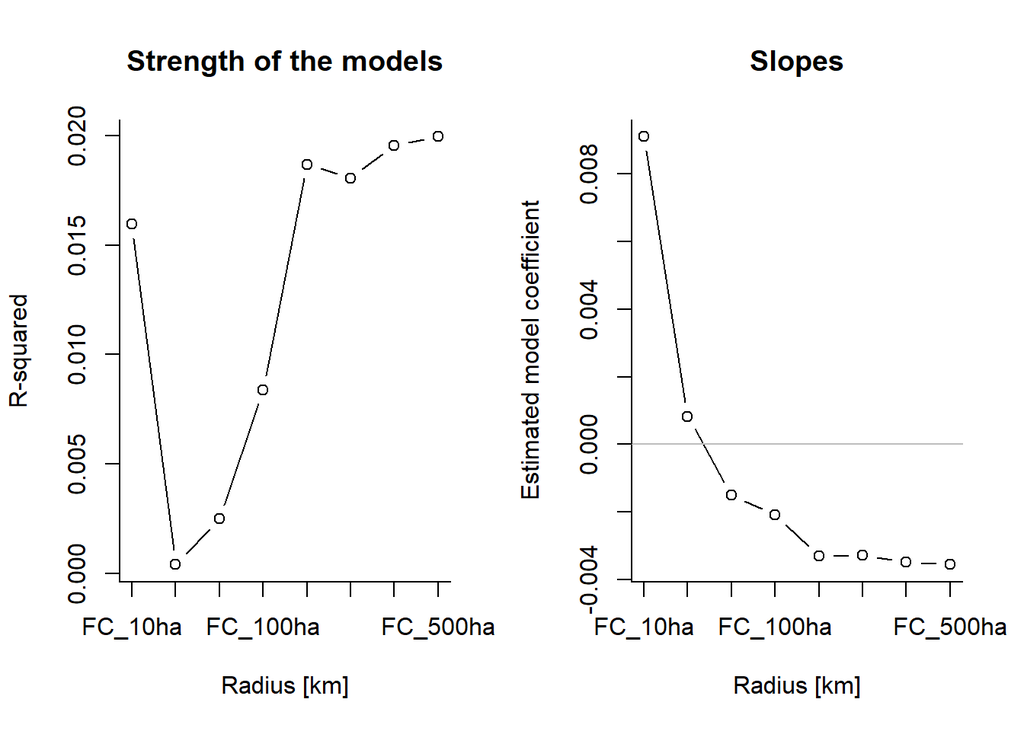

```r
Fric_FC_Una<- multifit(mod = "lm", multief = colnames(data_Una)[19:26],
                       formula = SES_Fric ~ multief,
                       data = data_Una, criterion = "R2", plot_est = T)
```

*Serra Tabuleiro*

```
## The model including the effect 'FC_400ha' was the best model according to the specified criterion (R2, which.max)
```

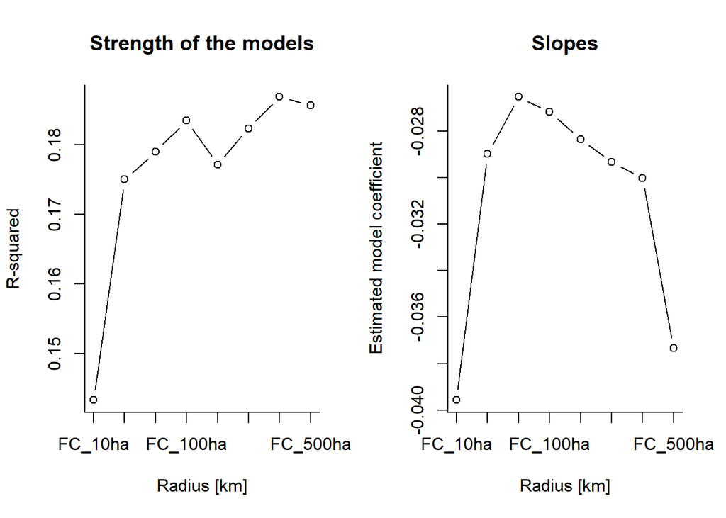

```r
Fric_FC_STB<- multifit(mod = "lm", multief = colnames(data_STB)[19:26],
                       formula = SES_Fric ~ multief,
                       data = data_STB, criterion = "R2", plot_est = T)
```

**FDis**